# Problem Set 2: Extra Credit

Author

James Supeyo Kibiro

Published

September 6, 2024

# Using regression to analyze TN STAR

In the main problem set, you partly worked through the famous Tennessee STAR study, which looked at the effect of smaller class size on student achievement. Here we’ll explore a bit more about the data set and look at subgroup variation.

First, let’s load some useful packages.

```r
library(tidyverse)
library(skimr) # Tidy summary statistics table
library(estimatr) # For "lm_robust"
```

##### Load in data set

Download the data set from bcourses and make sure that it’s in the same directory as your `Rmd` file.

Now let’s load the data set into `R`.

```r
load("TN_STAR_for_PS2_Bonus.RData")
```

Let’s make sure that we loaded it right.

```r
star |> glimpse()
```

```
Rows: 5,768
Columns: 6
$ treat            <fct> 1, 1, 0, 0, 1, 0, 0, 0, 1, 1, 0, 0, 1, 1, 0, 0, 0, 0,…
$ std_math_score_k <dbl> -0.26501451, 1.08392051, -0.47913118, 1.57638884, 0.0…
$ std_read_score_k <dbl> 0.329092142, 0.425180630, 0.072856176, 0.361121638, 0…
$ white            <fct> 1, 0, 0, 1, 1, 1, 0, 1, 0, 1, 1, 1, 1, 1, 1, 1, 1, 0,…
$ boy              <fct> 1, 1, 0, 0, 0, 0, 1, 1, 1, 1, 0, 0, 0, 0, 0, 0, 1, 1,…
$ free_lunch       <fct> 0, 0, 1, 0, 1, 1, 1, 0, 0, 0, 0, 0, 0, 0, 0, 0, 1, 1,…
```

```r
star |> skim()
```

Data summary

| Name | star |
| --- | --- |
| Number of rows | 5768 |
| Number of columns | 6 |
| _______________________ |  |
| Column type frequency: |  |
| factor | 4 |
| numeric | 2 |
| ________________________ |  |
| Group variables | None |

**Variable type: factor**

| skim_variable | n_missing | complete_rate | ordered | n_unique | top_counts |
| --- | --- | --- | --- | --- | --- |
| treat | 0 | 1 | FALSE | 2 | 0: 4035, 1: 1733 |
| white | 0 | 1 | FALSE | 2 | 1: 3889, 0: 1879 |
| boy | 0 | 1 | FALSE | 2 | 0: 2962, 1: 2806 |
| free_lunch | 0 | 1 | FALSE | 2 | 0: 2982, 1: 2786 |

**Variable type: numeric**

| skim_variable | n_missing | complete_rate | mean | sd | p0 | p25 | p50 | p75 | p100 | hist |
| --- | --- | --- | --- | --- | --- | --- | --- | --- | --- | --- |
| std_math_score_k | 0 | 1 | 0 | 1.02 | -3.54 | -0.67 | -0.03 | 0.59 | 3.01 | ▁▂▇▅▁ |
| std_read_score_k | 0 | 1 | 0 | 1.02 | -3.90 | -0.73 | -0.12 | 0.52 | 6.09 | ▁▇▅▁▁ |

So far so good. We’ve greatly simplified the data set here: `boy` and `white` are the relevant indicators for self-reported gender and race; `free_lunch` is an indicator for free or reduced-price lunch status, which is generally available for low-income students; `treat` is the indicator for random assignment to treatment.

Our outcome variables of interest are standardized test scores at the end of Kindergarten in math and reading: `std_math_score_k` and `std_read_score_k`.

### Visualize your data

Here is a boxplot of the overall distribution of `std_math_score_k` in our study sample.

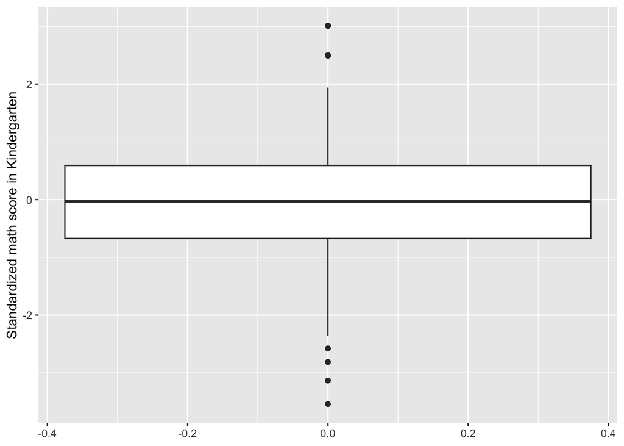

```r
ggplot(star, aes(y = std_math_score_k)) +
  geom_boxplot() +
  labs(y = "Standardized math score in Kindergarten")
```

#### Question (a)

Plot the distribution of test scores separately for white vs. non-white students. (You’re welcome to stick with a boxplot, but you’re also welcome to change!)

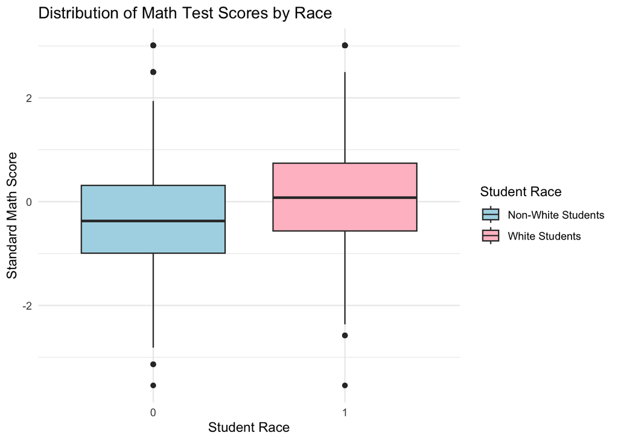

```r
ggplot(star, aes(x = white, y = std_math_score_k, fill = white))+
  geom_boxplot()+
  labs(title = "Distribution of Math Test Scores by Race",
       x= "Student Race",
       y= "Standard Math Score",
       fill="Student Race")+
  scale_fill_manual(values = c("0"="lightblue","1"="pink"),
                    labels = c("Non-White Students", "White Students"))+
  theme_minimal()
```

#### Question (b)

Plot the distribution of test scores separately by treatment status. Is there any (visual) evidence of an effect on math score?

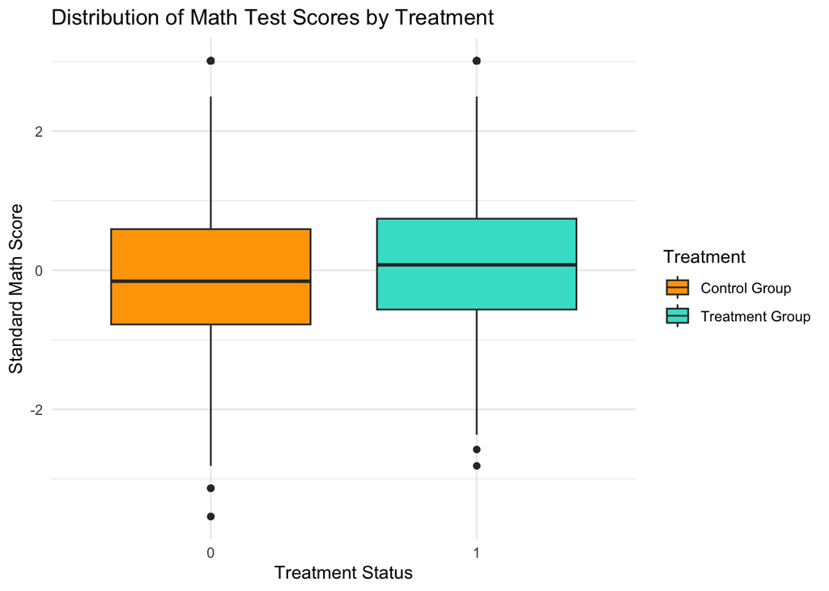

```r
ggplot(star, aes(x = treat, y = std_math_score_k, fill = treat))+
  geom_boxplot()+
  labs(title = "Distribution of Math Test Scores by Treatment",
       x= "Treatment Status",
       y= "Standard Math Score",
       fill="Treatment")+
  scale_fill_manual(values = c("0"="orange","1"="turquoise"),
                    labels = c("Control Group", "Treatment Group"))+
  theme_minimal()
```

#### Question (c)

Plot the distribution of test scores separately by treatment status *and* race. What can you say?

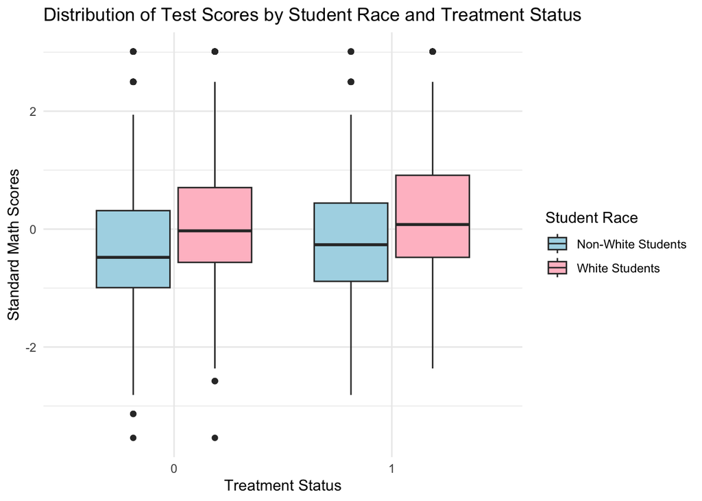

```r
ggplot(star, aes( x = treat, y = std_math_score_k, fill = white))+
  geom_boxplot()+
  labs(title = "Distribution of Test Scores by Student Race and Treatment Status",
         x= "Treatment Status",
       y = "Standard Math Scores",
       fill="Student Race")+
  scale_fill_manual(values = c("0" = "lightblue", "1" = "pink"),
                    labels = c("Non-White Students", "White Students"))+
  theme_minimal()
```

### Estimate impacts

#### Question (d)

Replicating your answer from Question 2 in the main problem set, use regression to estimate the impact of being assigned to a small class on students’ end-of-kindergarten math scores (in SD units).

```r
lm_robust(std_math_score_k ~ treat, data = star)
```

```
               Estimate Std. Error   t value     Pr(>|t|)    CI Lower
(Intercept) -0.04933773 0.01575580 -3.131401 1.748448e-03 -0.08022502
treat1       0.17980277 0.02992711  6.008023 1.992814e-09  0.12113439
               CI Upper   DF
(Intercept) -0.01845045 5766
treat1       0.23847114 5766
```

#### Question (e)

Estimate the impact of small class size separately by `white`. Does the impact appear larger for one group? Which one?

```r
# Regression for White students

white_students_regression <- lm_robust(std_math_score_k ~ 1, data = star[star$white == 1,])

# Regression for Non-White students

non_white_students_regression <- lm_robust(std_math_score_k ~ 1, data = star[star$white == 0,])

white_students_regression
```

```
             Estimate Std. Error  t value     Pr(>|t|)   CI Lower  CI Upper
(Intercept) 0.1282136 0.01586235 8.082885 8.366557e-16 0.09711426 0.1593129
              DF
(Intercept) 3888
```

```r
non_white_students_regression
```

```
             Estimate Std. Error   t value    Pr(>|t|)   CI Lower  CI Upper
(Intercept) -0.250987 0.02402267 -10.44792 7.09512e-25 -0.2981009 -0.203873
              DF
(Intercept) 1878
```

#### Question (f)

Check your intuition from Question (e) by fitting a linear regression with an interaction by `white`. What does this tell you about treatment effect variation by white / non-white?

```r
model_interaction <- lm(std_math_score_k ~ 1 * white, data = star)

summary(model_interaction)
```

```
Call:
lm(formula = std_math_score_k ~ 1 * white, data = star)

Residuals:
    Min      1Q  Median      3Q     Max
-3.5457 -0.6765 -0.0342  0.5868  3.0063

Coefficients:
            Estimate Std. Error t value Pr(>|t|)
(Intercept) 0.004684   0.013456   0.348    0.728

Residual standard error: 1.022 on 5767 degrees of freedom
```

#### Question (g)

As we discussed in class, it’s often a good idea to adjust for pre-treatment covariates when estimating the treatment effect in a randomized trial. Re-estimate the effect of treatment on standardized kindergarten math score, adjusting for the available pre-treatment covariates. How much smaller is the standard error compared to the unadjusted version? (*Hint:* Careful about which variables in the data set are pre-treatment!)

```r
# Identify pretreatment covariates: boy (gender), white (race)

# Fit a linear regression model that includes the treatment variable and these covariates.

unadjusted_model <- lm_robust(std_math_score_k ~ 1, data = star)

summary(unadjusted_model)
```

```
Call:
lm_robust(formula = std_math_score_k ~ 1, data = star)

Standard error type:  HC2

Coefficients:
            Estimate Std. Error t value Pr(>|t|) CI Lower CI Upper   DF
(Intercept) 0.004684    0.01346  0.3481   0.7278  -0.0217  0.03106 5767

Multiple R-squared:  7.55e-15 , Adjusted R-squared:  7.55e-15
```

```r
# Extract the standard error for the treatment effect (class_size = small = 1)

unadjusted_se <- summary(unadjusted_model)$coefficients[1, "Std. Error"]

print(unadjusted_se)
```

```
[1] 0.0134562
```

```r
# Fit the Adjusted Model (With Pre-Treatment Covariates)

# adjusted_model <- lm(std_math_score ~ class_size + race + gender + parent_education, data = star)

adjusted_model <- lm_robust(std_math_score_k ~ 1 + 1 + 1 , data = star)

summary(adjusted_model)
```

```
Call:
lm_robust(formula = std_math_score_k ~ 1 + 1 + 1, data = star)

Standard error type:  HC2

Coefficients:
            Estimate Std. Error t value Pr(>|t|) CI Lower CI Upper   DF
(Intercept) 0.004684    0.01346  0.3481   0.7278  -0.0217  0.03106 5767

Multiple R-squared:  7.55e-15 , Adjusted R-squared:  7.55e-15
```

```r
# Extract the standard error for the treatment effect (class_size)

adjusted_se <- summary(adjusted_model)$coefficients[1, "Std. Error"]

print(adjusted_se)
```

```
[1] 0.0134562
```

```r
# Let's compare the standard errors

reduction_in_se <- unadjusted_se - adjusted_se

reduction_in_se
```

```
[1] 0
```

```r
percentage_reduction <- (reduction_in_se / unadjusted_se) * 100

print(percentage_reduction)
```

```
[1] 0
```

```r
cat("Unadjusted Standard Error:", unadjusted_se, "\n")
```

```
Unadjusted Standard Error: 0.0134562
```

```r
cat("Adjusted Standard Error:", adjusted_se, "\n")
```

```
Adjusted Standard Error: 0.0134562
```

```r
cat("Reduction in Standard Error:", reduction_in_se, "\n")
```

```
Reduction in Standard Error: 0
```

```r
cat("Percentage Reduction in SE:", percentage_reduction, "%\n")
```

```
Percentage Reduction in SE: 0 %
```